# Heart attacks & creatinine kinase

Gavin Simpson

10/10/2022

## Packages

Load the following packages

```r
pkgs <- c("readr", "dplyr", "ggplot2", "here")
vapply(pkgs, library, logical(1L), character.only = TRUE, logical.return = TRUE)
```

```
## here() starts at C:/Users/brand/OneDrive - Universite de Montreal/Bureau/Maitrise/Formations/physalia-gam-course
```

```
##   readr   dplyr ggplot2    here
##    TRUE    TRUE    TRUE    TRUE
```

## Data

The data are contained in `data/heart-attack.csv`, and consist of three variables

1. `ck`, the creatinine kinase level for each patient. The original paper binned patients into groups of CK levels. Here we use the mid points of the bins,
2. `attack`, the number of patients who experienced a heart attack
3. `ok`, the number of patients who did not experience a heart attack

Load the data into R

```r
ck <- read_csv(here("data", "heart-attack.csv"), col_types = "ddd")
ck
```

```
## # A tibble: 12 × 3
##       ck attack    ok
##    <dbl>  <dbl> <dbl>
##  1    20      2    88
##  2    60     13    26
##  3   100     30     8
##  4   140     30     5
##  5   180     21     0
##  6   220     19     1
##  7   260     18     1
##  8   300     13     1
##  9   340     19     1
## 10   380     15     0
## 11   420      7     0
## 12   460      8     0
```

## Data wrangling

Create a variables in `ck` for:

1. `total` — the total number of patients in each `ck` bin, and
2. `proportion` — the proportion of the total number of patients that suffered a heart attack

```r
ck <- ck %>%
  mutate(total = attack + ok,
         proportion = attack / total)
```

## Task

1. Produce a plot of the proportion of patients who suffered a heart attack vs the creatinine kinase level in the patient’s blood

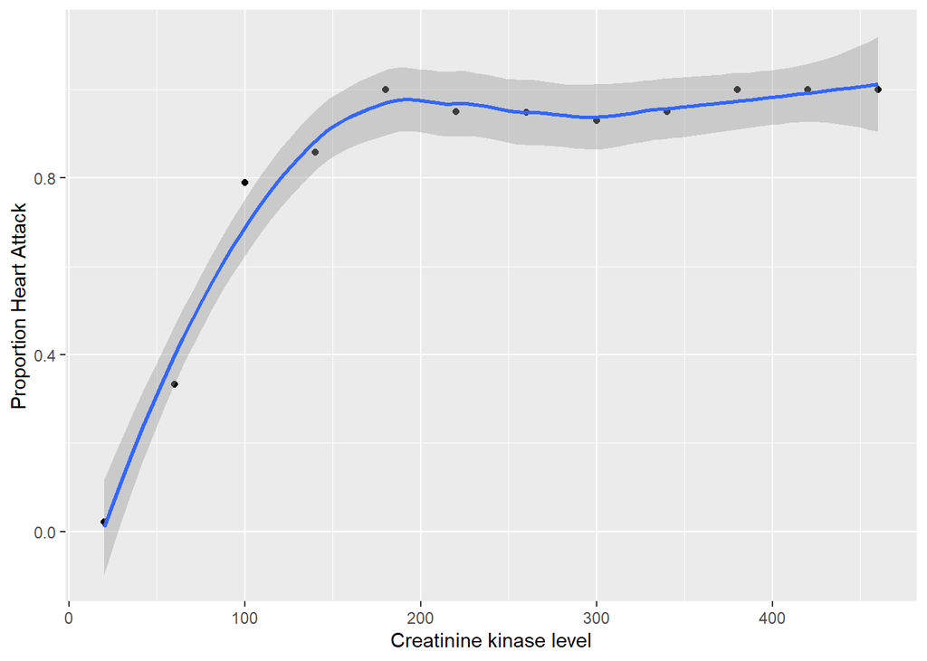

```r
ck %>%
    ggplot(aes( x = ck, y = proportion))+
    geom_point()+
    geom_smooth(method = "loess") +
  labs(x = "Creatinine kinase level", y = "Proportion Heart Attack")
```

2. Fit a binomial GLM (logit link) using the `glm()` to model the proportion of patients who suffered a heart attack as a function of the creatinine kinase level in the patient’s blood

   Hint: If you’re not sure how to specify the response for the GLM, read the *Details* section of `?glm`. You can use either the

   ```
    * two-column matrix version or,
    * the proportion as response but specify total counts via the `weights` argument
   ```

```r
m_ck <-  glm(proportion ~ ck, data = ck, family = binomial("logit"),
                         weights = total)
```

3. Produce the model summary using `summary()`

   Is the effect of `ck` on the proportion of patients with heart attacks statistically significant?

   **yes**

   What is the proportion of deviance explained?

```r
summary(m_ck)
```

```
##
## Call:
## glm(formula = proportion ~ ck, family = binomial("logit"), data = ck,
##     weights = total)
##
## Deviance Residuals:
##      Min        1Q    Median        3Q       Max
## -3.08184  -1.93008   0.01652   0.41772   2.60362
##
## Coefficients:
##              Estimate Std. Error z value Pr(>|z|)
## (Intercept) -2.758358   0.336696  -8.192 2.56e-16 ***
## ck           0.031244   0.003619   8.633  < 2e-16 ***
## ---
## Signif. codes:  0 '***' 0.001 '**' 0.01 '*' 0.05 '.' 0.1 ' ' 1
##
## (Dispersion parameter for binomial family taken to be 1)
##
##     Null deviance: 271.712  on 11  degrees of freedom
## Residual deviance:  36.929  on 10  degrees of freedom
## AIC: 62.334
##
## Number of Fisher Scoring iterations: 6
```

4. Calculate a quick goodness of fit test for the model using the information provided on the residual deviance
5. Plot the model diagnostics
6. Add fitted values of the model as a line on to the plot you created earlier
7. Looking at the model diagnostics and the plot of the fitted values versus the data, identify a problem with this model. Describe the problem in a few words.
8. Modify your model to account for the identified problem

   Hint: use ploynomials of `ck`
9. Look at the model summary, model diagnostic plots, and perform the goodness of fit test on the residual deviance. Are there any problems with this model?
10. Compare the two models using AIC and a generalized likelihood ratio test (GLRT). Which model is to be preferred?

    Hint: the `anova()` function is used to do the GLRT